# Lab-2.1: Assignment

`Gathering text data with an API`

**NOTE**: It is recommended that you complete this `.ipynb` file in VS-code.

`Submission:`

- Export the completed assignment to HTML or PDF (preferably with Quarto) and upload it to Canvas.
- The final uploaded version should NOT have any code-errors present
- All outputs must be visible in the uploaded version, including code-cell outputs, images, graphs, etc

## Assignment-1:

- Read over the `News-API`, `Wikipedia API`, and `Google Scholar` API sections in the lab-demonstration section, if you have not done so already.
- Get an API key for the `News-API`: [see following link](https://newsapi.org/docs/get-started)
- **Submission**: Insert your API key below

```python
API_KEY='476857e2dbfe4997b0eae3e04631330d'
```

## Assignment-2:

- Use the provided `News-API` code as a starting point
- Select `THREE` random topics (e.g. Georgetown, Cats, Clouds) but choose whatever you like
- Query the API to pull text data and store the results in three different dictionaries
- Extract the `title` and `description` text and store for later processing (up to you how you do this)
- Clean the text as needed

```python
import requests

# Insert api key
API_KEY = '476857e2dbfe4997b0eae3e04631330d'

topics = ['NBA', 'Car', 'Climate Change']

# Dictionary to store results
results = {}

# Query for each topic
for topic in topics:
    url = f'https://newsapi.org/v2/everything?qInTitle={topic}&language=en&apiKey={API_KEY}'
    response = requests.get(url)
    data = response.json()
# Make sure 'articles' exists
if 'articles' in data:
    articles = data['articles']
# Extract the title and description
    results[topic] = [{
    'title': article['title'] if article['title'] else 'No title available',
    'description': article['description'] if article['description'] else 'No description available'
    } for article in articles]

# Results
for topic, articles in results.items():
    print(f"Topic: {topic}")
    for article in articles:
        print(f"Title: {article['title']}")
        print(f"Description: {article['description']}\n")
```

```
Topic: Climate Change
Title: The Multiple Ways Climate Change Threatens to Make Migraines Worse
Description: Migraine sufferers are often triggered by the weather, and research suggests warming temperatures and more extreme weather events worsen attacks.

Title: The United Nations Wants to Treat AI With the Same Urgency as Climate Change
Description: A UN report proposes that the organization take a much more active role in the monitoring and oversight of AI.

Title: Will carbon capture help the UK tackle climate change?
Description: Will the plan announced today make a difference to the planet and is it worth the huge price tag?

Title: How did volcanism trigger climate change before the eruptions started?
Description: New dating of a major ancient warming shows warming started before major eruptions.

Title: Droughts likely to be even longer in the future due to climate change
Description: Major climate reports may be underselling the risks of rising emissions.

Title: California farmers turn to agave amid drought conditions and climate change
Description: Farmers in California are trying to plant crops that don't require a lot of water. Some are turning to growing agave as a response to a warming state.

Title: A landslide linked to climate change ‘rang’ the Earth for 9 days, researchers say
Description: The scale of the geological event is like something from prehistoric times, with a tsunami 200 meters--656 feet--in height. But it happened last year. Researchers warn that similar events may reoccur.

Title: Climate change makes farming easier in Alaska. Indigenous growers hope to lead the way
Description: Climate change threatens many traditional foods in Alaska. But it’s also making farming more possible. A new training program aims to help Alaska Native communities grow more of their own food.

Title: Europe's intense rainfall in September twice as likely thanks to climate change
Description: Extensive early warnings and years of adaptation made the floods less deadly than they otherwise might have been.

Title: Supreme Court refuses, for now, to block new EPA rules to fight climate change
Description: The justices, in a break from the way they have handled most such cases in the recent past, told the challengers to first litigate their claims in the U.S. Court of Appeals for the District of Columbia.

Title: Harris and Trump’s post-debate plans. And, why climate change puts chocolate at risk
Description: Former President Donald Trump and Vice President Harris are campaigning in swing states heavily post their first presidential debate. And, why climate change could put chocolate in danger.

Title: Hungry for new podcasts? Here are 8 episodes about how climate change affects our food
Description: Add these episodes to your listening rotation during the NPR Network's Climate Solutions Week, where we're dedicated to stories and conversations about the search for climate solutions.

Title: To Incentivize Companies to Address Climate Change, Measure Their Broader Impact
Description: Current climate reporting focuses primarily on reducing carbon emissions within companies’ direct operations and value chains, often overlooking the broader impact businesses can have on society. This narrow approach fails to recognize or reward companies for…

```

[output cut: 254 more lines]

```
Description: Farmer Jon Old tells the BBC that rising temperatures are making growing his crops more difficult.

Title: Beyond New Construction: The Urgent Need For Retrofitting In The Fight Against Climate Change
Description: The road to clean energy and decarbonization of our built environment has never been more relevant than it is today.

Title: Fossil-Fueled Climate Change Left Out of Media Coverage of Hurricane Helene: Scientist Peter Kalmus
Description: Hurricane Helene tears through the southeastern United States as scientists say climate change rapidly intensifies hurricanes. The storm devastated large swaths of the southeastern United States after making landfall in Florida as a Category 4 storm. Official…

Title: Trump: People Aren't Buying Climate Change 'Scam' Anymore
Description: Morning Joe did a little compare and contrast about each candidate's reaction to climate change after the devastation of Hurricane Helene.

"HARRIS: And we will stand with these communities for as long as it takes to make sure that they are able to recover an…

Title: [Removed]
Description: [Removed]
```

## Assignment-3:

- Use the provided `Wikipedia-API` code as a starting point
- Select `THREE` random topics (e.g. Georgetown, Cats, Clouds) but choose whatever you like
- Query the API to pull text data and store the results locally
- For EACH `THREE` of the random topics, create a `word cloud` for your cleaned text

```python
import wikipediaapi

# Initialize Wikipedia API with a generic User-Agent
wiki_wiki = wikipediaapi.Wikipedia(
    language='en',
    user_agent="DSAN5000_Lab_Project/1.0 (Data Science Project)"
)

# Topics to query
topics = ['NBA', 'Car', 'Climate Change']

# Dictionary to store results
wiki_results = {}

# Query Wikipedia for each topic
for topic in topics:
    page = wiki_wiki.page(topic)
    if page.exists():
        wiki_results[topic] = page.text
    else:
        wiki_results[topic] = "Page not found."

# Check the results
for topic, text in wiki_results.items():
    print(f"Topic: {topic}")
    print(f"Extracted Text: {text[:500]}...")  # Only show the first 500 characters
```

```
Topic: NBA
Extracted Text: The National Basketball Association (NBA) is a professional basketball league in North America composed of 30 teams (29 in the United States and 1 in Canada). It is one of the major professional sports leagues in the United States and Canada and is considered the premier professional…
The NBA was created on August 3, 1949, with the merger of the Basketball Association of America (BAA) and the National Basketball League (NBL). The league later adopted the BAA's hist...
Topic: Car
Extracted Text: A car, or an automobile, is a motor vehicle with wheels. Most definitions of cars state that they run primarily on roads, seat one to eight people, have four wheels, and mainly transport people over cargo. There are around one billion cars in use worldwide. The car is considered an e…
The French inventor Nicolas-Joseph Cugnot built the first steam-powered road vehicle in 1769, while the Swiss inventor François Isaac de Rivaz designed and constructed the firs...
Topic: Climate Change
Extracted Text: In common usage, climate change describes global warming—the ongoing increase in global average temperature—and its effects on Earth's climate system. Climate change in a broader sense also includes previous long-term changes to Earth's climate. The current rise in global average tem…
```

```python
import re

def clean_text(text):
    # Remove special characters and numbers, keep only letters
    text = re.sub(r'[^a-zA-Z\s]', '', text)
    # Convert to lowercase
    text = text.lower()
    return text

# Clean the text for each topic
cleaned_results = {topic: clean_text(text) for topic, text in wiki_results.items()}
```

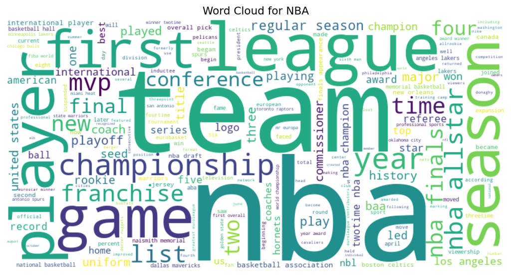

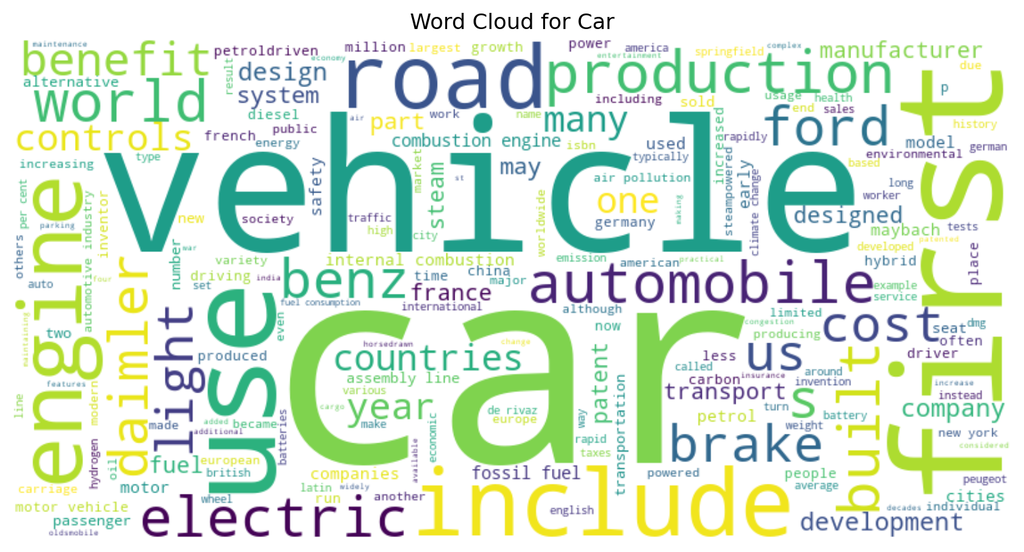

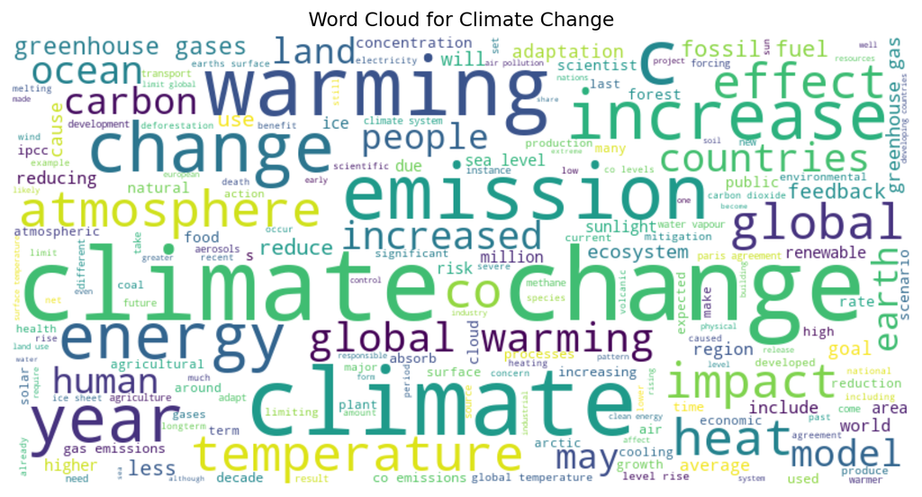

```python
from wordcloud import WordCloud
import matplotlib.pyplot as plt

# Generate word cloud for each topic
for topic, text in cleaned_results.items():
    wordcloud = WordCloud(width=800, height=400, background_color='white').generate(text)

    # Display the word cloud
    plt.figure(figsize=(10, 5))
    plt.imshow(wordcloud, interpolation='bilinear')
    plt.axis('off')
    plt.title(f"Word Cloud for {topic}")
    plt.show()
```